# Exercise 1

This exercise requires setting up `mirt()` for estimating IRT models with the data provided, and requires applying some useful generic functions to be used on the estimated objects following convergence. The data is available in the `Exercise_01.Rdata` file.

Load the dataset into R using the `load()` function, and inspect the defined objects. The object named `data` represents an unscored multiple choice test, where each number indicates which category was selected, while the `key` object provides the scoring key (indicates which category is correct).

### 1) Use `key2binary()` to convert `data` into a new object that indicates correct responses (call it `scored.data`).

```r
library(mirt)
load('Exercise_01.Rdata')
head(data)
```

```
##      Item_1 Item_2 Item_3 Item_4 Item_5 Item_6 Item_7 Item_8 Item_9
## [1,]      2      2      4      4      1      5      2      1      2
## [2,]      3      3      4      1      5      5      5      5      3
## [3,]      3      2      1      5      5      4      1      5      5
## [4,]      2      5      1      3      5      1      4      2      2
## [5,]      3      4      4      5      5      3      3      1      5
## [6,]      4      2      1      5      5      4      5      2      4
##      Item_10 Item_11 Item_12 Item_13 Item_14 Item_15 Item_16 Item_17
## [1,]       2       3       1       5       3       2       4       5
## [2,]       4       5       4       4       3       5       3       5
## [3,]       1       5       5       1       3       2       1       4
## [4,]       4       1       1       5       3       1       1       5
## [5,]       3       5       3       1       5       5       5       3
## [6,]       1       5       3       1       3       5       5       3
##      Item_18 Item_19 Item_20 Item_21 Item_22 Item_23 Item_24 Item_25
```

[output cut: 34 more lines]

```r
print(key)
```

```
##  [1] 3 2 4 5 5 5 5 5 1 1 5 3 1 3 5 5 4 1 4 4 4 2 3 3 3 3 4 1 2 3 1 4 4 1 1
## [36] 5 1 3 4 5 5 1 4 4 5 1 5 3 2 2
```

```r
scored.data <- key2binary(data, key)
head(scored.data)
```

```
##      Item_1 Item_2 Item_3 Item_4 Item_5 Item_6 Item_7 Item_8 Item_9
## [1,]      0      1      1      0      0      1      0      0      0
## [2,]      1      0      1      0      1      1      1      1      0
## [3,]      1      1      0      1      1      0      0      1      0
## [4,]      0      0      0      0      1      0      0      0      0
## [5,]      1      0      1      1      1      0      0      0      0
## [6,]      0      1      0      1      1      0      1      0      0
##      Item_10 Item_11 Item_12 Item_13 Item_14 Item_15 Item_16 Item_17
## [1,]       0       0       0       0       1       0       0       0
## [2,]       0       1       0       0       1       1       0       0
## [3,]       1       1       0       1       1       0       0       1
## [4,]       0       0       0       0       1       0       0       0
## [5,]       0       1       1       1       0       1       1       0
## [6,]       1       1       1       1       1       1       1       0
##      Item_18 Item_19 Item_20 Item_21 Item_22 Item_23 Item_24 Item_25
```

[output cut: 34 more lines]

### 2) Find some general statistical information about this test (means, sds, total scores, etc) to get a feel for the `scored.dat` object. Following that, fit a unidimensional 2PL model for each item and print the model to the R console.

```r
psych::describe(scored.data)
```

```
##         vars    n   mean        sd median trimmed    mad min max range
## Item_1     1 2500 0.3860 0.4869280    0.0  0.3575 0.0000   0   1     1
## Item_2     2 2500 0.4324 0.4955083    0.0  0.4155 0.0000   0   1     1
## Item_3     3 2500 0.6364 0.4811316    1.0  0.6705 0.0000   0   1     1
## Item_4     4 2500 0.4744 0.4994441    0.0  0.4680 0.0000   0   1     1
## Item_5     5 2500 0.5620 0.4962404    1.0  0.5775 0.0000   0   1     1
## Item_6     6 2500 0.4792 0.4996671    0.0  0.4740 0.0000   0   1     1
## Item_7     7 2500 0.5836 0.4930601    1.0  0.6045 0.0000   0   1     1
## Item_8     8 2500 0.3404 0.4739385    0.0  0.3005 0.0000   0   1     1
## Item_9     9 2500 0.4560 0.4981599    0.0  0.4450 0.0000   0   1     1
## Item_10   10 2500 0.5000 0.5001000    0.5  0.5000 0.7413   0   1     1
## Item_11   11 2500 0.5396 0.4985291    1.0  0.5495 0.0000   0   1     1
## Item_12   12 2500 0.4860 0.4999040    0.0  0.4825 0.0000   0   1     1
## Item_13   13 2500 0.4776 0.4995979    0.0  0.4720 0.0000   0   1     1
## Item_14   14 2500 0.6304 0.4827930    1.0  0.6630 0.0000   0   1     1
## Item_15   15 2500 0.5572 0.4968168    1.0  0.5715 0.0000   0   1     1
## Item_16   16 2500 0.4556 0.4981244    0.0  0.4445 0.0000   0   1     1
## Item_17   17 2500 0.5000 0.5001000    0.5  0.5000 0.7413   0   1     1
## Item_18   18 2500 0.5588 0.4966299    1.0  0.5735 0.0000   0   1     1
## Item_19   19 2500 0.3428 0.4747403    0.0  0.3035 0.0000   0   1     1
## Item_20   20 2500 0.5844 0.4929238    1.0  0.6055 0.0000   0   1     1
## Item_21   21 2500 0.6480 0.4776895    1.0  0.6850 0.0000   0   1     1
## Item_22   22 2500 0.4232 0.4941654    0.0  0.4040 0.0000   0   1     1
## Item_23   23 2500 0.4948 0.5000730    0.0  0.4935 0.0000   0   1     1
## Item_24   24 2500 0.3376 0.4729860    0.0  0.2970 0.0000   0   1     1
## Item_25   25 2500 0.4756 0.4995042    0.0  0.4695 0.0000   0   1     1
## Item_26   26 2500 0.5076 0.5000423    1.0  0.5095 0.0000   0   1     1
## Item_27   27 2500 0.4228 0.4941030    0.0  0.4035 0.0000   0   1     1
## Item_28   28 2500 0.4968 0.5000898    0.0  0.4960 0.0000   0   1     1
## Item_29   29 2500 0.4204 0.4937219    0.0  0.4005 0.0000   0   1     1
## Item_30   30 2500 0.4928 0.5000482    0.0  0.4910 0.0000   0   1     1
## Item_31   31 2500 0.4784 0.4996332    0.0  0.4730 0.0000   0   1     1
## Item_32   32 2500 0.5592 0.4965823    1.0  0.5740 0.0000   0   1     1
## Item_33   33 2500 0.5584 0.4966771    1.0  0.5730 0.0000   0   1     1
## Item_34   34 2500 0.6420 0.4795081    1.0  0.6775 0.0000   0   1     1
## Item_35   35 2500 0.5880 0.4922936    1.0  0.6100 0.0000   0   1     1
## Item_36   36 2500 0.4624 0.4986840    0.0  0.4530 0.0000   0   1     1
## Item_37   37 2500 0.4912 0.5000226    0.0  0.4890 0.0000   0   1     1
## Item_38   38 2500 0.6732 0.4691373    1.0  0.7165 0.0000   0   1     1
## Item_39   39 2500 0.3860 0.4869280    0.0  0.3575 0.0000   0   1     1
```

[output cut: 47 more lines]

```
## Item_36  0.15073658 -1.978069 0.009973680
## Item_37  0.03518433 -1.999561 0.010000451
## Item_38 -0.73808126 -1.455818 0.009382746
## Item_39  0.46805445 -1.781637 0.009738559
## Item_40  0.01439173 -2.000593 0.010001741
## Item_41 -0.78709712 -1.381030 0.009306436
## Item_42  1.77115107  1.137432 0.007485920
## Item_43  0.37585188 -1.859479 0.009829728
## Item_44 -0.03998400 -1.999200 0.010000000
## Item_45  0.39781843 -1.842477 0.009809597
## Item_46  0.53464765 -1.714837 0.009662313
## Item_47  0.07360570 -1.995380 0.009995226
## Item_48  0.49765261 -1.753043 0.009705701
## Item_49  0.18467281 -1.966682 0.009959582
## Item_50 -0.57937127 -1.664994 0.009606574
```

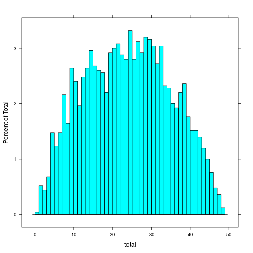

```r
total <- rowSums(scored.data)
histogram(~total, breaks=50)
```

```r
unidim <- mirt(scored.data, 1)
```

```
##
Iteration: 1, Log-Lik: -74599.370, Max-Change: 1.77049
Iteration: 2, Log-Lik: -73154.668, Max-Change: 0.26344
Iteration: 3, Log-Lik: -73102.539, Max-Change: 0.06859
Iteration: 4, Log-Lik: -73081.567, Max-Change: 0.04932
Iteration: 5, Log-Lik: -73069.377, Max-Change: 0.03432
Iteration: 6, Log-Lik: -73062.085, Max-Change: 0.02864
Iteration: 7, Log-Lik: -73057.571, Max-Change: 0.02181
Iteration: 8, Log-Lik: -73054.757, Max-Change: 0.01766
Iteration: 9, Log-Lik: -73052.948, Max-Change: 0.01520
Iteration: 10, Log-Lik: -73049.768, Max-Change: 0.00617
Iteration: 11, Log-Lik: -73049.690, Max-Change: 0.00314
Iteration: 12, Log-Lik: -73049.645, Max-Change: 0.00242
Iteration: 13, Log-Lik: -73049.551, Max-Change: 0.00056
Iteration: 14, Log-Lik: -73049.550, Max-Change: 0.00032
Iteration: 15, Log-Lik: -73049.549, Max-Change: 0.00029
Iteration: 16, Log-Lik: -73049.546, Max-Change: 0.00091
Iteration: 17, Log-Lik: -73049.545, Max-Change: 0.00011
Iteration: 18, Log-Lik: -73049.545, Max-Change: 0.00009
```

```r
print(unidim)
```

```
##
## Call:
## mirt(data = scored.data, model = 1)
##
## Full-information item factor analysis with 1 factor(s).
## Converged within 1e-04 tolerance after 18 EM iterations.
## mirt version: 1.8
## M-step optimizer: BFGS
## EM acceleration: Ramsay
## Number of rectangular quadrature: 41
##
## Log-likelihood = -73049.54
## AIC = 146299.1; AICc = 146307.5
## BIC = 146881.5; SABIC = 146563.8
```

### 3) Try inspecting the converged model by using `coef()`, `summary()`, `plot()`, and `itemplot()`. Understand the output of the functions by referring to the `?mirt` and `?itemplot` documentation.

```r
coef(unidim, simplify=TRUE)
```

```
## $items
##             a1      d g u
## Item_1   0.747 -0.520 0 1
## Item_2   1.523 -0.382 0 1
## Item_3   0.846  0.646 0 1
## Item_4   1.107 -0.126 0 1
## Item_5   0.608  0.271 0 1
## Item_6   0.744 -0.093 0 1
## Item_7   0.969  0.405 0 1
## Item_8   1.314 -0.872 0 1
## Item_9   1.346 -0.234 0 1
## Item_10  1.664  0.004 0 1
## Item_11  1.381  0.219 0 1
## Item_12  1.319 -0.072 0 1
## Item_13  1.013 -0.107 0 1
## Item_14  0.824  0.613 0 1
## Item_15  0.939  0.274 0 1
## Item_16  0.712 -0.197 0 1
## Item_17  1.210  0.003 0 1
## Item_18  1.079  0.294 0 1
## Item_19  1.034 -0.789 0 1
## Item_20  1.381  0.465 0 1
## Item_21  0.854  0.706 0 1
## Item_22  0.608 -0.335 0 1
## Item_23  1.360 -0.025 0 1
## Item_24  0.934 -0.794 0 1
## Item_25  0.963 -0.115 0 1
## Item_26  1.020  0.039 0 1
## Item_27  1.055 -0.380 0 1
## Item_28  1.772 -0.015 0 1
## Item_29  1.685 -0.474 0 1
## Item_30  1.267 -0.035 0 1
## Item_31  1.196 -0.108 0 1
## Item_32  1.027  0.291 0 1
## Item_33  1.657  0.351 0 1
## Item_34  1.346  0.784 0 1
## Item_35  1.431  0.493 0 1
## Item_36  0.716 -0.167 0 1
## Item_37  1.662 -0.048 0 1
## Item_38  1.003  0.871 0 1
## Item_39  1.390 -0.627 0 1
## Item_40  1.163 -0.016 0 1
## Item_41  1.825  1.191 0 1
## Item_42 -1.416 -2.134 0 1
## Item_43  1.761 -0.565 0 1
## Item_44  1.208  0.054 0 1
## Item_45  1.150 -0.497 0 1
## Item_46  1.308 -0.697 0 1
## Item_47  1.504 -0.100 0 1
## Item_48  1.187 -0.626 0 1
## Item_49  0.800 -0.209 0 1
## Item_50  0.834  0.658 0 1
##
## $groupPars
## $groupPars$means
## MEAN_1
##      0
##
## $groupPars$cov
##    F1
## F1  1
```

```r
summary(unidim)
```

```
##             F1    h2
## Item_1   0.402 0.161
## Item_2   0.667 0.445
## Item_3   0.445 0.198
## Item_4   0.545 0.297
## Item_5   0.336 0.113
## Item_6   0.401 0.160
## Item_7   0.495 0.245
## Item_8   0.611 0.373
## Item_9   0.620 0.385
## Item_10  0.699 0.489
## Item_11  0.630 0.397
## Item_12  0.612 0.375
## Item_13  0.511 0.262
## Item_14  0.436 0.190
## Item_15  0.483 0.233
## Item_16  0.386 0.149
## Item_17  0.579 0.336
## Item_18  0.535 0.287
## Item_19  0.519 0.269
## Item_20  0.630 0.397
## Item_21  0.448 0.201
## Item_22  0.336 0.113
## Item_23  0.624 0.390
## Item_24  0.481 0.232
## Item_25  0.492 0.242
## Item_26  0.514 0.264
## Item_27  0.527 0.278
## Item_28  0.721 0.520
## Item_29  0.703 0.495
## Item_30  0.597 0.357
## Item_31  0.575 0.330
## Item_32  0.517 0.267
## Item_33  0.698 0.487
## Item_34  0.620 0.385
## Item_35  0.644 0.414
## Item_36  0.388 0.150
## Item_37  0.699 0.488
## Item_38  0.508 0.258
## Item_39  0.633 0.400
## Item_40  0.564 0.318
## Item_41  0.731 0.535
## Item_42 -0.639 0.409
## Item_43  0.719 0.517
## Item_44  0.579 0.335
## Item_45  0.560 0.313
## Item_46  0.609 0.371
## Item_47  0.662 0.438
## Item_48  0.572 0.327
## Item_49  0.425 0.181
## Item_50  0.440 0.194
##
## SS loadings:  15.97
## Proportion Var:  0.319
##
## Factor correlations:
##
##    F1
## F1  1
```

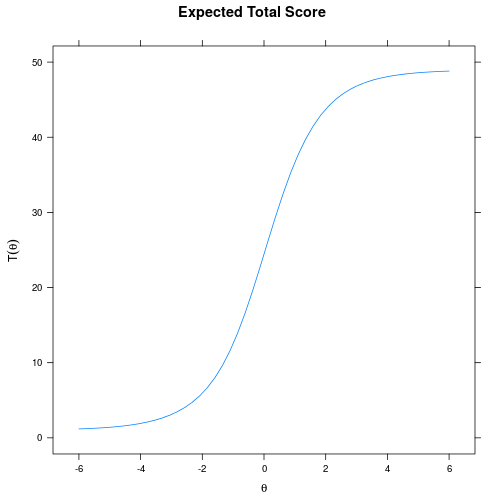

```r
plot(unidim)
```

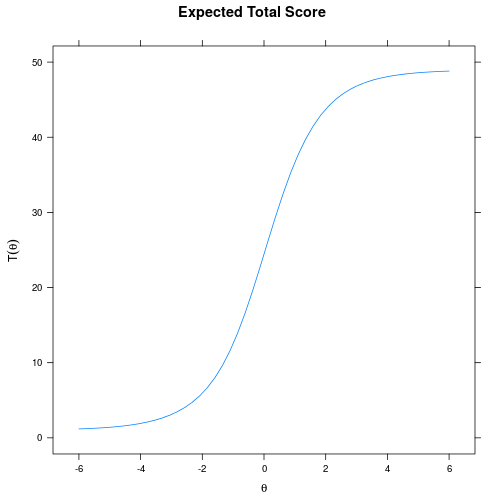

```r
plot(unidim, type = 'score')
```

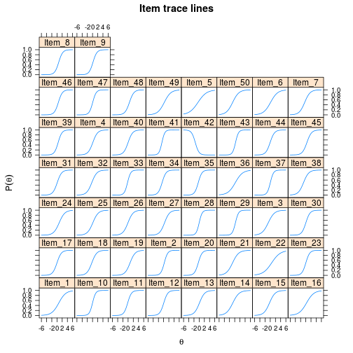

```r
plot(unidim, type = 'trace', auto.key = FALSE)
```

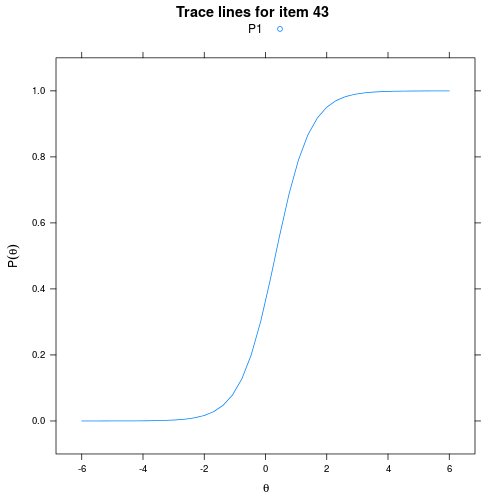

```r
# item 42 has backwards discrimination compared to other items
itemplot(unidim, 43)
```

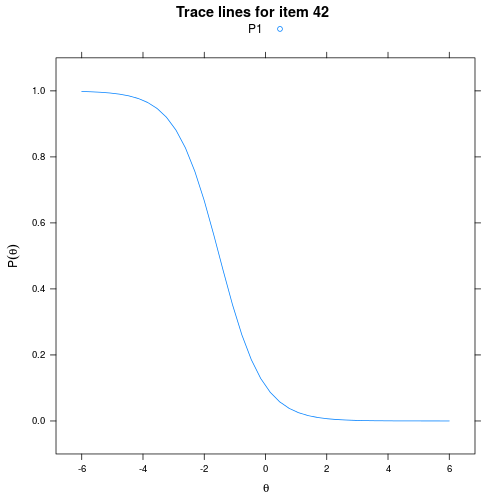

```r
itemplot(unidim, 42)
```

### 4) One item appears to stand out more than the rest for some reason (detectable even without the use of itemfit statistics). You suspect that the key supplied for that item is either reverse coded or incorrect. Replace the scored item with the original data from `data`, and modify the default `itemtype` argument to fit a nominal response model for only this item. What do you notice about the probability tracelines for this item?

```r
newdata <- scored.data
newdata[,42] <- data[,42]

itemtype <- rep('2PL', 50)
itemtype[42] <- 'nominal'
newmod <- mirt(newdata, 1, itemtype=itemtype)
```

```
## 'nominal.highlow' matrix not specified, highest and lowest categories are used by default
```

```
##
Iteration: 1, Log-Lik: -78763.987, Max-Change: 3.20035
Iteration: 2, Log-Lik: -75296.726, Max-Change: 5.18710
Iteration: 3, Log-Lik: -75101.192, Max-Change: 1.75137
Iteration: 4, Log-Lik: -75066.921, Max-Change: 0.22171
Iteration: 5, Log-Lik: -75060.635, Max-Change: 0.07485
Iteration: 6, Log-Lik: -75057.290, Max-Change: 0.01785
Iteration: 7, Log-Lik: -75055.415, Max-Change: 0.01499
Iteration: 8, Log-Lik: -75053.824, Max-Change: 0.01271
Iteration: 9, Log-Lik: -75052.727, Max-Change: 0.00977
Iteration: 10, Log-Lik: -75050.192, Max-Change: 0.00354
Iteration: 11, Log-Lik: -75050.099, Max-Change: 0.00301
Iteration: 12, Log-Lik: -75050.012, Max-Change: 0.00377
Iteration: 13, Log-Lik: -75049.849, Max-Change: 0.00288
Iteration: 14, Log-Lik: -75049.790, Max-Change: 0.00163
Iteration: 15, Log-Lik: -75049.755, Max-Change: 0.00180
Iteration: 16, Log-Lik: -75049.874, Max-Change: 0.00542
Iteration: 17, Log-Lik: -75049.625, Max-Change: 0.00303
Iteration: 18, Log-Lik: -75049.600, Max-Change: 0.00272
Iteration: 19, Log-Lik: -75049.552, Max-Change: 0.00072
Iteration: 20, Log-Lik: -75049.541, Max-Change: 0.00080
Iteration: 21, Log-Lik: -75049.530, Max-Change: 0.00172
Iteration: 22, Log-Lik: -75049.513, Max-Change: 0.00108
Iteration: 23, Log-Lik: -75049.503, Max-Change: 0.00029
Iteration: 24, Log-Lik: -75049.502, Max-Change: 0.00014
Iteration: 25, Log-Lik: -75049.502, Max-Change: 0.00057
Iteration: 26, Log-Lik: -75049.501, Max-Change: 0.00029
Iteration: 27, Log-Lik: -75049.500, Max-Change: 0.00043
Iteration: 28, Log-Lik: -75049.499, Max-Change: 0.00089
Iteration: 29, Log-Lik: -75049.491, Max-Change: 0.00023
Iteration: 30, Log-Lik: -75049.490, Max-Change: 0.00012
Iteration: 31, Log-Lik: -75049.490, Max-Change: 0.00048
Iteration: 32, Log-Lik: -75049.489, Max-Change: 0.00024
Iteration: 33, Log-Lik: -75049.488, Max-Change: 0.00035
Iteration: 34, Log-Lik: -75049.488, Max-Change: 0.00028
Iteration: 35, Log-Lik: -75049.487, Max-Change: 0.00042
Iteration: 36, Log-Lik: -75049.486, Max-Change: 0.00021
Iteration: 37, Log-Lik: -75049.486, Max-Change: 0.00017
Iteration: 38, Log-Lik: -75049.485, Max-Change: 0.00024
Iteration: 39, Log-Lik: -75049.485, Max-Change: 0.00012
```

[output cut: 13 more lines]

```
Iteration: 53, Log-Lik: -75049.477, Max-Change: 0.00037
Iteration: 54, Log-Lik: -75049.477, Max-Change: 0.00019
Iteration: 55, Log-Lik: -75049.477, Max-Change: 0.00015
Iteration: 56, Log-Lik: -75049.476, Max-Change: 0.00022
Iteration: 57, Log-Lik: -75049.476, Max-Change: 0.00011
Iteration: 58, Log-Lik: -75049.476, Max-Change: 0.00044
Iteration: 59, Log-Lik: -75049.475, Max-Change: 0.00022
Iteration: 60, Log-Lik: -75049.475, Max-Change: 0.00033
Iteration: 61, Log-Lik: -75049.474, Max-Change: 0.00027
Iteration: 62, Log-Lik: -75049.473, Max-Change: 0.00040
Iteration: 63, Log-Lik: -75049.473, Max-Change: 0.00020
Iteration: 64, Log-Lik: -75049.473, Max-Change: 0.00016
Iteration: 65, Log-Lik: -75049.472, Max-Change: 0.00023
Iteration: 66, Log-Lik: -75049.472, Max-Change: 0.00012
Iteration: 67, Log-Lik: -75049.472, Max-Change: 0.00009
```

```r
key[42] #1 scored as correct
```

```
## [1] 1
```

```r
# looks as if the 2nd category is empirically higher than all the others (largest ak)
coef(newmod)[[42]]
```

```
##        a1 ak0    ak1   ak2 ak3 ak4 d0    d1    d2    d3    d4
## par 0.246   0 10.398 3.665 2.6   4  0 1.502 0.202 0.136 0.117
```

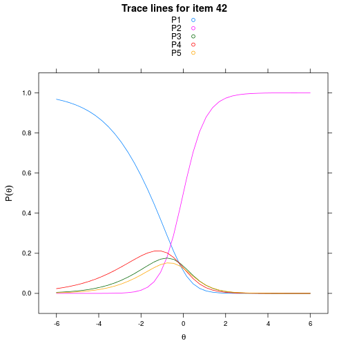

```r
itemplot(newmod, 42) #2nd category appears to be the correct traceline
```

### 5) Fix the key according to your observations, created a new dataset called `correct.scored.data`, and re-estimate the unidimenisonal 2PL model. How do the itemtrace and information curves look now?

```r
key[42] <- 2
correct.scored.data <- key2binary(data, key)
mod <- mirt(correct.scored.data, 1)
```

```
##
Iteration: 1, Log-Lik: -74253.849, Max-Change: 0.54836
Iteration: 2, Log-Lik: -73501.173, Max-Change: 0.15131
Iteration: 3, Log-Lik: -73442.814, Max-Change: 0.07965
Iteration: 4, Log-Lik: -73415.560, Max-Change: 0.05230
Iteration: 5, Log-Lik: -73399.075, Max-Change: 0.04634
Iteration: 6, Log-Lik: -73388.751, Max-Change: 0.03648
Iteration: 7, Log-Lik: -73382.120, Max-Change: 0.02771
Iteration: 8, Log-Lik: -73377.969, Max-Change: 0.02266
Iteration: 9, Log-Lik: -73375.307, Max-Change: 0.01843
Iteration: 10, Log-Lik: -73370.488, Max-Change: 0.00326
Iteration: 11, Log-Lik: -73370.424, Max-Change: 0.00292
Iteration: 12, Log-Lik: -73370.379, Max-Change: 0.00249
Iteration: 13, Log-Lik: -73370.283, Max-Change: 0.00022
Iteration: 14, Log-Lik: -73370.282, Max-Change: 0.00015
Iteration: 15, Log-Lik: -73370.282, Max-Change: 0.00014
Iteration: 16, Log-Lik: -73370.280, Max-Change: 0.00010
Iteration: 17, Log-Lik: -73370.280, Max-Change: 0.00009
```

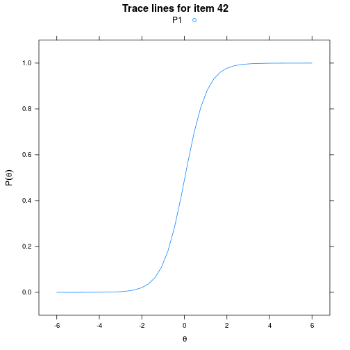

```r
itemplot(mod, 42)
```

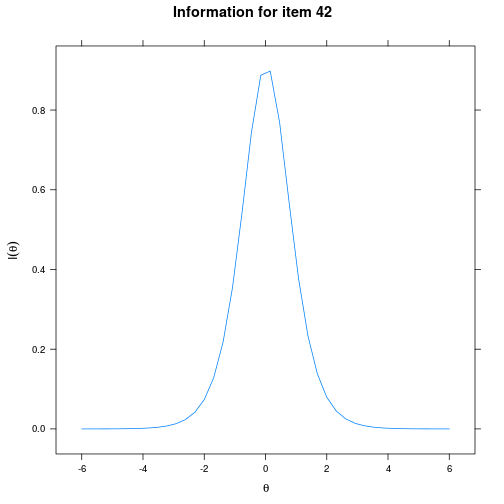

```r
itemplot(mod, 42, type = 'info')
```

### 6) We happened to discover that the peculiar item has two distinct slopes in the probability response curves. Large slopes in distractors options provide information about lower level individuals, in that if they pick this particular distractor we know more information about their particular \(\theta\) location than just that 'they didn't know the answer' (i.e., dichotomous scoring).Fit this item with the 'nestlogit' itemtype, and compare this item information curve to the corrected 2PL information curve. What do you notice?

```r
itemtype[42] <- '2PLNRM'
# nest logit models require scoring key
nestmod <- mirt(newdata, 1, itemtype=itemtype, key=key)
```

```
##
Iteration: 1, Log-Lik: -75943.953, Max-Change: 0.54503
Iteration: 2, Log-Lik: -75183.517, Max-Change: 0.17886
Iteration: 3, Log-Lik: -75120.055, Max-Change: 0.07740
Iteration: 4, Log-Lik: -75092.391, Max-Change: 0.06479
Iteration: 5, Log-Lik: -75075.599, Max-Change: 0.04318
Iteration: 6, Log-Lik: -75066.751, Max-Change: 0.03964
Iteration: 7, Log-Lik: -75060.536, Max-Change: 0.02943
Iteration: 8, Log-Lik: -75056.632, Max-Change: 0.02263
Iteration: 9, Log-Lik: -75054.248, Max-Change: 0.01758
Iteration: 10, Log-Lik: -75050.307, Max-Change: 0.00561
Iteration: 11, Log-Lik: -75050.127, Max-Change: 0.00515
Iteration: 12, Log-Lik: -75050.000, Max-Change: 0.00425
Iteration: 13, Log-Lik: -75049.775, Max-Change: 0.00067
Iteration: 14, Log-Lik: -75049.771, Max-Change: 0.00063
Iteration: 15, Log-Lik: -75049.768, Max-Change: 0.00025
Iteration: 16, Log-Lik: -75049.767, Max-Change: 0.00024
Iteration: 17, Log-Lik: -75049.766, Max-Change: 0.00024
Iteration: 18, Log-Lik: -75049.765, Max-Change: 0.00024
Iteration: 19, Log-Lik: -75049.762, Max-Change: 0.00089
Iteration: 20, Log-Lik: -75049.761, Max-Change: 0.00010
Iteration: 21, Log-Lik: -75049.761, Max-Change: 0.00009
```

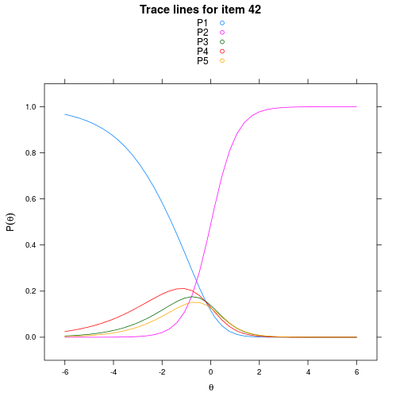

```r
itemplot(nestmod, 42)
```

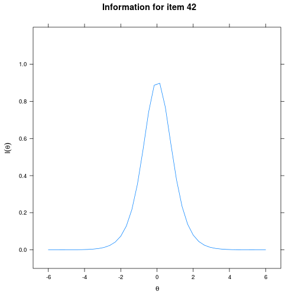

```r
itemplot(mod, 42, type= 'info', ylim=c(-.1,1.2))
```

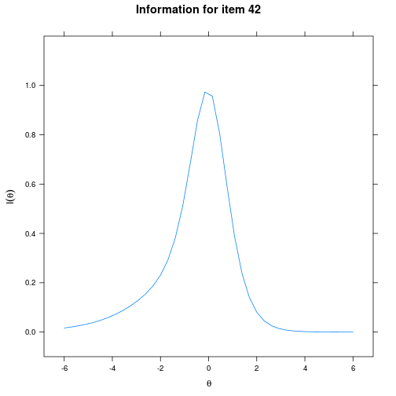

```r
# curve is higher in the lower end for nestlogit models, indicating more info about less able subjects
itemplot(nestmod, 42, type= 'info', ylim=c(-.1,1.2))
```